# STAT 240: Inference on Proportions

# Overview

## Learning Outcomes

- These lectures will teach you how to:
  - Conceptualize statistical inference on a single proportion and for a difference in proportions, through statistical models and p-values
  - Compute a confidence interval or p-value for inference on a single proportion and for a difference in proportions

## Preliminaries

- Download `week09-proportionInference.Rmd` to `STAT240/lecture/week09`.
- Download `chimpanzee.csv` to `COURSE/data`.

## Chimpanzee Data

- **Supplementary material** on the chimpanzee data can be found in [Chapter 17 of Professor Bret Larget’s Course Notes and Case Studies](https://bookdown.org/bret_larget/stat-240-case-studies/chimpanzees-and-prosocial-choice.html).
- This lecture will use the data in `chimpanzee.csv`. The data is based on an experiment conducted by scientists at Emory University in 2011; though those scientists did not make their true data public, we have created a “mock” dataset which gives the same results and summary values as their data.
- Two chimpanzees were put in adjacent enclosures with the ability to see and communicate with each other.
- One chimpanzee, the **actor**, was given the choice to pick from a bucket of tokens which were two different colors.
- The actor had previously been taught that one color would lead to the human researcher to give them (just the actor) a treat. We call this the **selfish** choice.
- The other color would lead to the human researcher giving **both the actor and the partner** a treat. We call this the “**prosocial**” choice.
- The **actor** was given this choice 30 times, and the number of **prosocial** and **selfish** choices were recorded.
- The researchers performed this experiment with many combinations of actors, partners, and colors; including observing their behavior when the actor had **no partner**.
- Our “mock” dataset for this can be found in `chimpanzee.csv`.

```r
chimpanzee = read_csv("../../data/chimpanzee.csv")
```

> Every row represents one 30-trial combination of actor and partner.

```r
head(chimpanzee)
```

```
## # A tibble: 6 × 6
##   actor partner prosocial selfish prosocial_color selfish_color
##   <chr> <chr>       <dbl>   <dbl> <chr>           <chr>
## 1 A     I              22       8 green           purple
## 2 A     G              16      14 yellow          black
## 3 A     H              22       8 blue            red
## 4 A     none           16      14 pink            gray
## 5 B     H              18      12 black           yellow
## 6 B     C              23       7 purple          green
```

- For example, when A was paired with I, they made 22/30 prosocial choices. When A had no partner (“none”), they made 16/30 prosocial choices.

### Exploring the Data

```r
sum1 = chimpanzee %>%
  mutate(session_type = case_when(
    partner == "none" ~ "no partner",
    TRUE ~ "partner"
  )) %>%
  group_by(actor, session_type) %>%
  summarize(prosocial = sum(prosocial),
            selfish = sum(selfish),
            n = prosocial + selfish,
            pct_prosocial = 100*prosocial/n)
sum1
```

```
## # A tibble: 13 × 6
## # Groups:   actor [7]
##    actor session_type prosocial selfish     n pct_prosocial
##    <chr> <chr>            <dbl>   <dbl> <dbl>         <dbl>
##  1 A     no partner          16      14    30          53.3
##  2 A     partner             60      30    90          66.7
##  3 B     no partner          16      14    30          53.3
##  4 B     partner             60      30    90          66.7
##  5 C     no partner          17      13    30          56.7
##  6 C     partner             57      33    90          63.3
##  7 D     no partner           8      22    30          26.7
##  8 D     partner             50      40    90          55.6
##  9 E     no partner          12      18    30          40
## 10 E     partner             48      42    90          53.3
## 11 F     no partner          14      16    30          46.7
## 12 F     partner             47      43    90          52.2
## 13 G     partner             37      33    70          52.9
```

```r
sum1_wide = sum1 %>%
  select(actor, session_type, pct_prosocial) %>%
  pivot_wider(names_from = session_type,
              values_from = pct_prosocial)

sum1_wide
```

```
## # A tibble: 7 × 3
## # Groups:   actor [7]
##   actor `no partner` partner
##   <chr>        <dbl>   <dbl>
## 1 A             53.3    66.7
## 2 B             53.3    66.7
## 3 C             56.7    63.3
## 4 D             26.7    55.6
## 5 E             40      53.3
## 6 F             46.7    52.2
## 7 G             NA      52.9
```

- We see that every chimpanzee made the pro-social choice more than half the time when a partner was present.
- Chimpanzee G had a smaller number of trials than the others and had no trials without a partner
- Each partner made the pro-social choice more often with a partner than without.

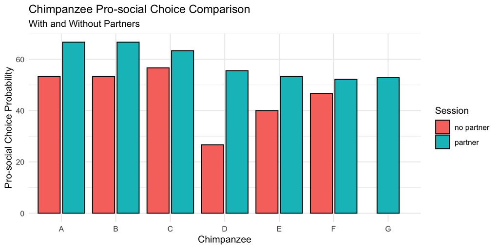

```r
ggplot(sum1, aes(x = actor, y = pct_prosocial,
                 fill = session_type)) +
  geom_col(color = "black",
           position = position_dodge2(preserve = "single")) +
  #scale_y_continuous(labels = percent_format(scale = 1)) +
  labs(
    x = "Chimpanzee",
    y = "Pro-social Choice Probability",
    title = "Chimpanzee Pro-social Choice Comparison",
    subtitle = "With and Without Partners",
    fill = "Session"
  ) +
  theme_minimal()
```

## Motivation

> The overall goal of the study was to investigate: **Do chimpanzees exhibit prosocial behavior?**

We observe the following summary data:

```r
chimpanzee %>%
  mutate(
    HadAPartner = (partner != "none")
  ) %>%
  group_by(HadAPartner) %>%
  summarize(totalChoices = sum(prosocial) + sum(selfish),
            numProsocial = sum(prosocial),
            percProsocial = 100*round(numProsocial/totalChoices,3)) %>%
  select(HadAPartner, numProsocial, totalChoices, percProsocial)
```

```
## # A tibble: 2 × 4
##   HadAPartner numProsocial totalChoices percProsocial
##   <lgl>              <dbl>        <dbl>         <dbl>
## 1 FALSE                 83          180          46.1
## 2 TRUE                 359          610          58.9
```

- We observe about 59% prosocial choice with a partner, and 46% prosocial choice without a partner.

# Inference on Proportions

- We can ask a couple different interesting inference questions here:

> Let the true probability of a chimpanzee picking prosocially with a partner be $p_{partner}$. Is $p_{partner}$ greater than 0.5?

> Let the true probability of a chimpanzee picking prosocially with no partner be $p_{no partner}$. Are $p_{no partner}$ and $p_{partner}$ equal?
- We will investigate both of these questions (in order) through confidence intervals and hypothesis testing.

##### Defining Variables

> **Question of interest:** Let the true probability of a chimpanzee picking prosocially with a partner be $p_{partner}$. Is $p_{partner}$ greater than 0.5?

Let $X$ be the number of observed prosocial choices among $n = 610$ chimpanzee trials with a partner.

Let $p$ be the unknown, true, underlying probability of any chimpanzee making the prosocial choice in a single trial with a partner. (Notice that we are assuming the same true $p$ for all chimpanzees, which may not be true.)

##### Model Statement

Then,

$$X \sim Binom(610, p)$$

##### Model Assumptions

- We may declare that $X$ follows a binomial distribution only if we accept the four binomial assumptions:
- **B**: The chimpanzee either makes the prosocial choice or does not.
- **I**: Each trial can be assumed to be independent of each other. (Remember, more art than science.)
- **N**: We have a fixed number of trials, $n = 610$.
- **S**: Each trial can be assumed to have the same true $p$ of “success”.

Note: The “population parameter” here is being described as a “true” proportion. We could also think of this as the proportion of times the chimpanzees would pick prosocially with infinitely many trials.

Alternatively, you can conceptualize this as some probabilistic psychological mechanism that exists in the chimpanzees’ brain dictating their actions, whether they are aware of that or not.

# Point Estimate and Sampling Distribution

- Some of the binomial assumptions in the original model we provided were a little sketchy. For example, some chimps may just be more selfish than others (violates **S**ame $p$ assumption), and chimps may treat their partner the way they are treated as a partner (violates **I**ndependence).
- For now, we will begin just by looking at chimpanzee A’s trials; because chimp A likely has a constant underlying $p$ throughout the experiment, and went first, so could not be reacting to external factors.

```r
chimpanzee %>%
  filter(actor == "A") %>%
  mutate(HadAPartner = (partner != "none")) %>%
  group_by(HadAPartner) %>%
  summarize(
            prosocialChoices = sum(prosocial),
            totalChoices = prosocialChoices + sum(selfish),
            percProsocial = 100*round(prosocialChoices/totalChoices,3)) %>%
  select(HadAPartner, percProsocial, prosocialChoices, totalChoices)
```

```
## # A tibble: 2 × 4
##   HadAPartner percProsocial prosocialChoices totalChoices
##   <lgl>               <dbl>            <dbl>        <dbl>
## 1 FALSE                53.3               16           30
## 2 TRUE                 66.7               60           90
```

- Our observed data here, among trials **with a partner** (as it relates to the true, underlying binomial distribution) is $X = 60$ prosocial choices from $n = 90$ trials.

### Point Estimate

- Here, our estimate of the true, unknown $p$ is $\hat{p} = 60/90 \approx 0.67$.

### Sampling Distribution of Point Estimate

- Through mathematical theory, we can derive that:

> Running $n$ independent trials with constant probability of success $p$ (e.g. one random value from $Binom(n, p)$ and then taking the proportion of successes among those $n$ points, call it $\hat{p}$, results in the distribution:

$$\hat{p} \stackrel{approx}\sim N(p, \sqrt{\frac{p(1-p)}{n}})$$

- This statement relies on the **normal approximation of binomial distributions** concept we learned a few weeks ago - which relies on $n*p$ not being small.
- Notice: The expected value of $\hat{p}$ is $p$! This is a desirable property of estimators generally.
- Notice: The standard error of $\hat{p}$ is $\sqrt{\frac{p(1-p)}{n}}$, which decreases when $n$ increases. More data, less variance in the predictions!
  - Note that this is based on the true, unknown $p$, which is a bummer. We will discuss later that we must estimate the standard error by replacing $p$ with $\hat{p}$.

### Investigate with Simulation

- With $n = 90$, let’s examine the distribution of $\hat{p} = X/n$ when $X \sim Binom(n, 60/90)$.
- Choose $B=1,000,000$ to repeat one million times (perhaps excessive).
- Set $p=60/90$.
- Set $n=90$.
- We will generate $B$ simulated random values, $X^*_1,\ldots,X^*_B$ where each $X_i \sim \text{Binomial}(90, 60/90)$.

```r
## simulation parameters
B = 1000000
n = 90
x = 60
p = x/n

## do the simulation
sim = tibble(
  x_star = rbinom(B, n, p),
  p_hat = x_star / n)

## summarize the simulation
sim_summary = sim %>%
  summarize(mean = mean(p_hat),  ## this should be very close to p=60/90=0.667
            sd = sd(p_hat)) ## this should be very close to sqrt(2/3 * 1/3 / 90) = 0.0497
sim_summary
```

```
## # A tibble: 1 × 2
##    mean     sd
##   <dbl>  <dbl>
## 1 0.667 0.0497
```

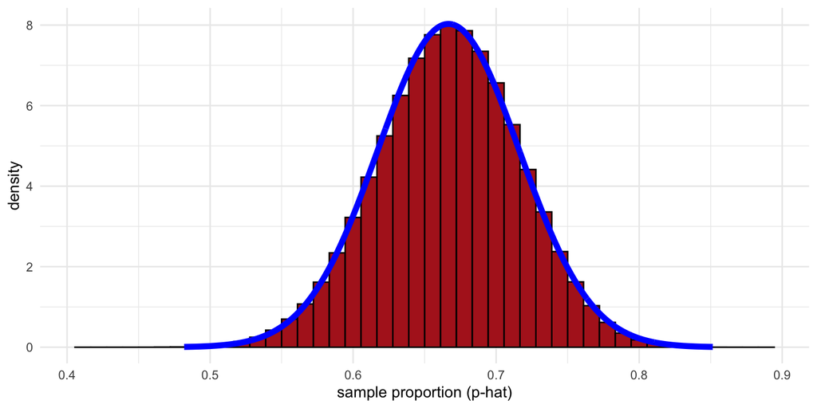

```r
## Graph of simulated p_hat values
ggplot(sim, aes(x = p_hat, y=after_stat(density))) +
  geom_histogram(center = 60/90, binwidth = 1/90,
                 color = "black", fill = "firebrick") +
  xlab("sample proportion (p-hat)") +
  theme_minimal() +
  # Theoretical sampling distribution
  geom_norm_density(mu=p, sigma=sqrt(p*(1-p)/n),color="blue", size=2)
```

- We have verified that the distribution is normal, as expected - and the parameters align with what we expected from theory.
- Now that we know the **sampling distribution** of $\hat{p}$ and its **standard error**, we can construct a confidence interval for $p$.

# Confidence Interval For A Single Proportion

- Recall our general form for a confidence interval

$$\text{Point Estimate } \pm \text{ Quantile Confidence Score * Standard
Error of PE}$$

- Where the **point estimate** is your estimate of the true parameter based on your data… (such as the sample proportion $\hat{p}$ for the true $p$, or the sample mean $\bar{x}$ for the true $\mu$)
- … the **quantile confidence score** (a.k.a “critical value”) is the ($\alpha$ + (1-$\alpha$)/2) quantile of the sampling distribution… (where your confidence level is $C = 1 - \alpha$)…
- and the **standard error of the point estimate** is a known formula based on what point estimate you are using.

## Visualization

- I have written the function `visualizeProportionCI` just as a visual aid to help you understand confidence intervals.
- **We saw this earlier in week 8 when we introduced regression, but now we are going to explore it further.**
- You give it the **true p** you are trying to estimate and a **sample size**, and it will generate a random point estimate and plot the confidence interval over it.
- For example, here’s a random point estimate and associated confidence interval of our true $p = 0.4$ with $n = 20$ at confidence level 95%:

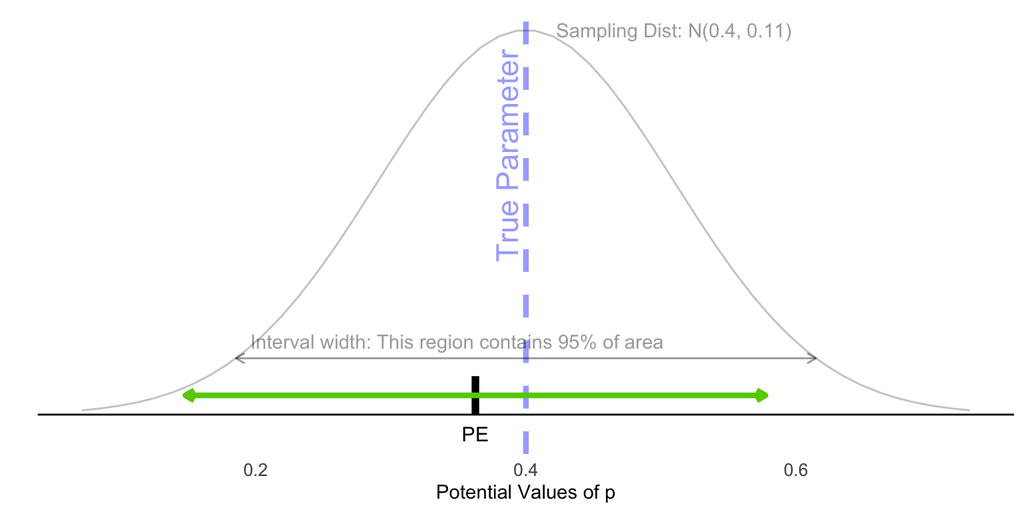

```r
visualizeProportionCI(true_p = 0.4, sample_size = 20, conf.level = 0.95)
```

- Watch our interval width **decrease** (see the sampling error and the labels on the x axis decrease) as we increase sample size:

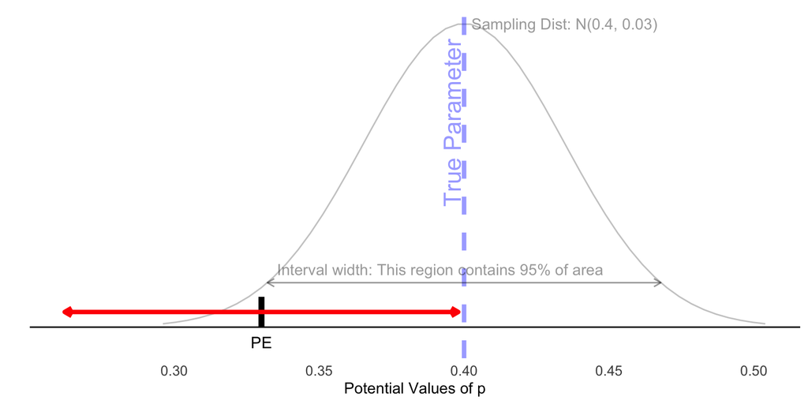

```r
visualizeProportionCI(true_p = 0.4, sample_size = 200, conf.level = 0.95)
```

- Finally, notice that if we were to decrease our **confidence level**, our interval would get **smaller**, and therefore be less likely to contain the real $p$.

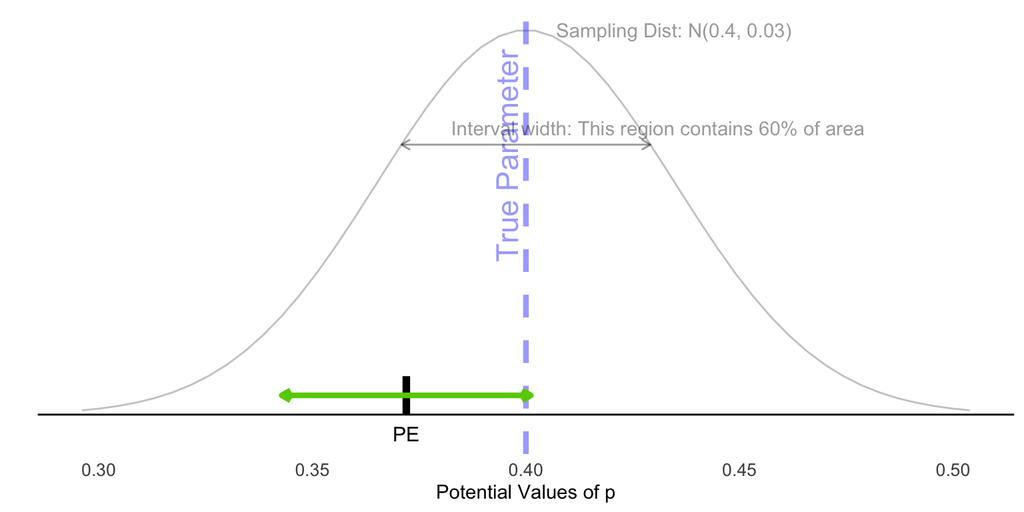

```r
# I strongly encourage you to run this a few times in your console to watch its behavior over many runs! Try to get one which doesn't contain the true p!
visualizeProportionCI(true_p = 0.4, sample_size = 200, conf.level = 0.6)
```

- In practice, we do not know what the true value of $p$ is, so we just get a “blind” confidence interval; you can see this with the `theory = FALSE` argument to the `visualizeProportionCI` function.

```r
visualizeProportionCI(true_p, sample_size = 20, theory = FALSE)
```

```
## Error in eval(expr, envir, enclos): object 'true_p' not found
```

## P-Hat Adjustments

- However, we still have a problem.
- The confidence interval for $p$ is based on $SE(\hat{p}) = \sqrt{\frac{p(1-p)}{n}}$… which is based on $p$, which we don’t know.
- Luckily, statisticians have come up with a couple workarounds for this.

### The Wald Adjustment

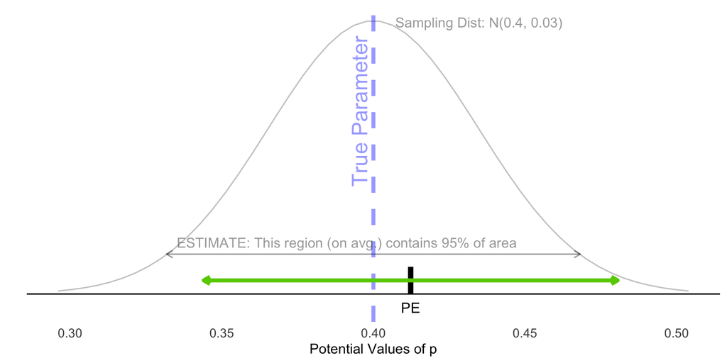

```r
visualizeProportionCI(true_p = 0.4, sample_size = 200, conf.level = 0.95, wald = TRUE)
```

- With the Wald adjustment, we now have a formula for the confidence interval for a single proportion based on **just our data**.

### Wald CI For a Proportion

$$\hat{p} \pm \text{qnorm}(\alpha+(1-\alpha)/2) *
\sqrt{\frac{\hat{p}(1-\hat{p})}{n}}$$

- This formula will contain the true value of $p$ $C = 1-\alpha$% of the time.
- Harken back to our chimpanzee example, where we don’t know the true $p$.

```r
# Three inputs; successes, sample size, confidence level
x = 60
n = 90
conf.level = 0.95

# Calculate Wald confidence interval
phat = x/n
se = sqrt(phat * (1 - phat)/n) # Wald adjustment replaces p with phat
moe = qnorm(conf.level + (1 - conf.level)/2) * se

left = phat - moe
right = phat + moe

c(left, right)
```

```
## [1] 0.5692753 0.7640581
```

#### Interpretation

> We are **95% confident** that the **true probability of Chimpanzee A making a prosocial choice with a partner** is between 56.9% and 76.4% (with the Wald adjustment).

### Agresti-Coull CI For a Proportion

- The **Wald** estimate is pretty solid and is widely used, but there is another adjustment which is slightly better at covering the true parameter.

> The **Agresti-Coull* adjustment adds two successes and two failures to the dataset artificially. This changes $X$ to $X+2$ and $n$ to $n+4$. These changes carry through to the point estimate, which is passed into the standard error.
- The Agresti-Coull adjustment **pulls towards 0.5**, especially away from the extremes of 0 and 1, which tends to be a more stable, reliable estimate.
  - To motivate this, consider estimating the probability a baseball player hits a home run on a given pitch. You watch this player take 10 pitches, and they never hit a home run.
  - Your $\hat{p}$ is 0, and your $SE(\hat{p})$ is therefore 0, and the math breaks down.
  - The Agresti-Coull adjustment prevents this, and extreme cases like it.

$$\hat{p}_{AC} = \frac{X + 2}{n +4}$$

$$\hat{p}_{AC} \pm \text{qnorm}(\alpha+(1-\alpha)/2) *
\sqrt{\frac{\hat{p}_{AC}(1-\hat{p}_{AC})}{n+4}}$$

- The Wald 95% CI was 56.9% to 76.4%.
- Here is the Agresti-Coull CI:

```r
# Three inputs; successes, sample size, confidence level
x = 60
n = 90
conf.level = 0.95

# Calculate AC confidence interval
x_adjusted = x+2 # Added two successes
n_adjusted = n+4 # Added four data points total
phat = x_adjusted/n_adjusted
se = sqrt(phat * (1 - phat)/n_adjusted)  # Changes carry through to p_hat and n_adjusted
moe = qnorm(conf.level + (1 - conf.level)/2) * se

left = phat - moe
right = phat + moe

c(left, right)
```

```
## [1] 0.5637829 0.7553660
```

#### Interpretation

> We are **95% confident** that the **true probability of a chimpanzee making a prosocial choice with a partner** is between 56.4% and 75.5% (with the Agresti-Coull adjustment).
- This interval is shifted a little closer to 50% than the Wald one was.

### Why Agresti-Coull?

- Earlier I claimed that the Agresti-Coull adjustment was “better” than the Wald adjustment. What do we mean by that?
- Both “adjustments” mean that the probability the interval contains the true $p$ (called the “coverage probability”) won’t be *exactly* your confidence level $1-\alpha$; it will fluctuate slightly around $1-\alpha$.
- The only truly 95% confidence interval uses the real $p$, which is pointless. However…

> The Agresti-Coull adjustment, **in practice**, usually leads to intervals with HIGHER than $1-\alpha$ coverage probability, especially for extreme $\hat{p}$. The Wald adjustment **in practice** usually leads to lower than $1-\alpha$ coverage probability, especially for extreme $\hat{p}$.
- The following graphs demonstrate this point; you aren’t responsible for knowing this code or graph at a deep level, just know that the above statement is backed up by the following analysis.

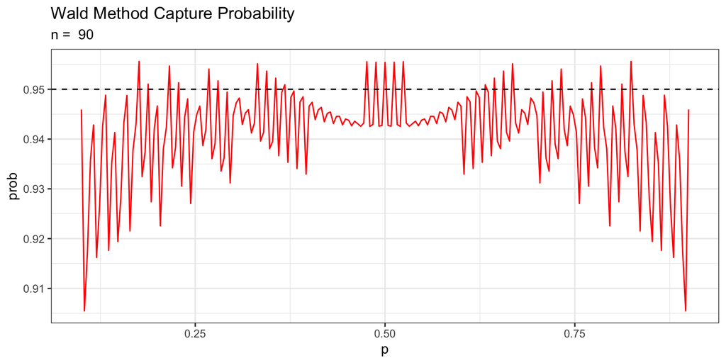

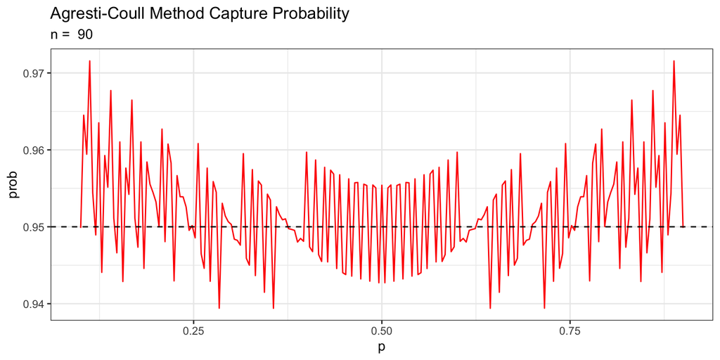

- The graphical evidence suggests that the Agresti-Coull adjustment is a better choice than the Wald adjustment.

# CI for $p$: In Summary

$$\text{Point Estimate } \pm \text{ Quantile Confidence Score * Standard
Error of PE}$$

- For estimating the true $p$, the point estimate is $\hat{p} = X/n$, the sample proportion.
  - When making the **Agresti-Coull adjustment**, your point estimate is $\hat{p}_{AC} = \frac{X+2}{n+4}$.
- The sampling distribution of $\hat{p}$ is normal, so the quantile confidence score is `qnorm(1-alpha + alpha/2)`.
  - For the common confidence level 95% ($\alpha = 0.05$), this value is `qnorm(0.975) = 1.96`.
  - This only depends on your confidence level.
- The standard error of $\hat{p}$ is based off of $p$ which we don’t know.
  - If we are just making the Wald adjustment, the standard error is $\sqrt{\frac{\hat{p}(1-\hat{p})}{n}}$.
  - However, when we make the **Agresti-Coull adjustment** it is $\sqrt{\frac{\hat{p}_{AC}(1-\hat{p}_{AC})}{n+4}}$.

# Hypothesis Testing For $p$

## Step 1: Model Statement

- We will return to the chimpanzee A data as an example, who picked the prosocial choice 60 times out of 90 total trials with a partner.

##### Defining Variables

Let $X$ be the number of observed prosocial choices among $n = 90$ chimpanzee A trials with a partner.

Let $p$ be the unknown, true, underlying probability of chimpanzee A making the prosocial choice in a single trial with a partner. (*This is the parameter of interest*.)

##### Model Statement

With these definitions,

$$X \sim Binom(90, p)$$

##### Model Assumptions

- We may declare that $X$ follows a binomial distribution only if we accept the four binomial assumptions:
- **B**: Chimpanzee A either makes the prosocial choice or does not.
- **I**: Each trial can be assumed to be independent of each other.
- **N**: We have a fixed number of trials, $n = 90$.
- **S**: Each trial can be assumed to have the same true $p$ of “success”.

## Step 2: State Hypotheses

- Recall that the **null hypothesis** (for the purposes of this class) is always of the form `true parameter value = some number`, and captures the idea that there is **no meaningful pattern**, or **no meaningful relationship**, et cetera.
- Furthermore, the **alternative hypothesis** is of the form `true parameter value \neq that same number` or `true parameter value > that same number` or `true parameter value < that same number`. It captures the idea that there is **is a meaningful pattern or relationship** in your data.
- The alternative is the statement we WANT to prove, but have to show indirectly through disproving the null.
- With the chimpanzee data, we can test the null hypothesis that $p = 0.5$; the idea that the chimps are picking randomly between the colors, they really aren’t considering their partner at all.
- The alternative hypothesis, or the idea that the chimps ARE picking prosocially more often than random, is $p > 0.5$.
- In statistical notation:

$$H_0: p = 0.5$$

$$H_A: p > 0.5$$

## Step 3: Test Statistic and Null Distribution

- Recall that in order to find statistical evidence AGAINST the null hypothesis: we **assume the null hypothesis is true** (in this case $p = 0.5$), and then use some **test statistic** whose distribution is known when the null hypothesis is true.
- In this case, the test statistic comes straight from our model: we know that the observed number of successes $X \sim Binom(90, p)$.
- When we assume $p = 0.5$, this turns into $X \sim Binom(90, 0.5)$. That is our **null distribution**, which is fully known.

## Step 4: Identify Relevant Outcomes from Data + Alt. Hyp.

- We now bring in our observed data; in this case $X = 60$.
- We need to consider both the **observed data** and the **alternative hypothesis** (remember, the statement we actually want to prove) to determine the following set:

> Which values of the test statistic that are **as or less likely than the one we observed** (on the null distribution from step 3) also consitute **evidence for the alternative hypothesis?**
- Let’s look at the null distribution below, and annotate the observed value of our test statistic:

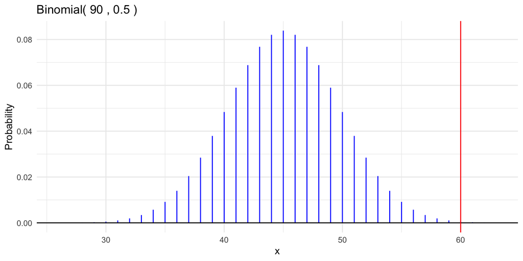

```r
null_p = 0.5

gbinom(90, null_p, scale = TRUE) +
  geom_vline(xintercept = 60, color = "red")
```

- The values which are **as or less likely** than our observed 60 are those greater than or equal to 60, AND those less than or equal to 30. (Because the null distribution among is symmetric, $p = 0.5$.)
- Recall that the alternative hypothesis was $p > 0.5$. The lower outcomes don’t constitute evidence for a large $p$, but the higher outcomes do. Therefore, our set of interest is **values greater than or equal to 60**.

## Step 5: Calculate P-Value

*Note: Keep p-value separate from “the value of $p$” in your head! That terminology can get a little confusing!*

- This is the **probability of observing an outcome in the set identified in step 4.** Note that since this is a probability, it should be between 0 and 1. Some p-values will get very very low, but should never be negative or greater than 1.
- On $Binom(90, 0.5)$ (the null distribution), the probability of getting 60 or greater should be small, according to the picture in step 4.

```r
# X ~ Binom(90, 0.5):
# P(X >= 60) = P(X > 59) = 1 - P(X <= 59) = 1 - pbinom(59, 90, 0.5)

1 - pbinom(59, 90, 0.5)
```

```
## [1] 0.001030133
```

- The **p-value** for this test is 0.001.

## Step 6: Interpret In Context

> We find strong evidence that Chimpanzee A is inclined to make the prosocial choice more often than randomly (p-value = 0.001, single proportion test).

# The Psychic Example

- A psychic is handed a random card from a deck, face down, and asked to determine what suit the card is without looking at it. (The card may be one of four suits, each with equal probability; “hearts”, “diamonds”, “spades”, or “clubs”).
- The psychic claims they can sometimes tell what the suit is without looking at the card.
- This experiment was repeated 200 times, and the psychic got the suit right 57 times.

> Conduct a hypothesis test to assess the evidence for the psychic’s ability.

**Step 1: Model and Assumptions**

Let $X$ be the observed number of correct guesses from $n = 200$ trials.

Let $p$ be the true probability of the psychic getting the suit right on an individual trial.

Then,

$$X \sim Binom(200, p)$$

We may verify the BINS assumptions; **B**: each trial is right or wrong, **I**: the trials are independent, **N**: There is a fixed sample size, $n = 200$, and **S**: each trial has the same probability of success, $p$.

**Step 2: State Hypotheses**

- The null hypothesis captures the idea that the psychic is picking randomly, or has no psychic ability.
- If the psychic is picking randomly, they have a 1 in 4 chance of getting the suit right.

$$H_0: p = 0.25$$

- The alternative hypothesis captures the thing that you seek to prove; that the psychic truly has a better-than-random chance of getting it right.

$$H_A: p > 0.25$$

**Step 3: Test Statistic and Null Distribution**

- We know that $X \sim Binom(200, p)$. Under the null hypothesis which states $p = 0.25$, $X \sim Binom(200, p)$.
- The observed data is X = 57.

**Step 4: Identify Relevant Outcomes**

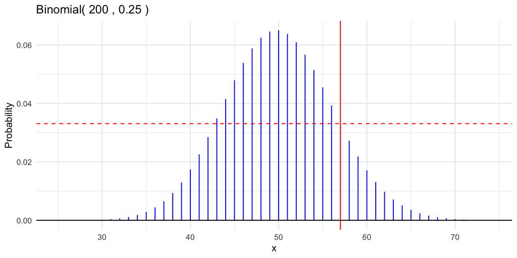

```r
gbinom(200, 0.25, scale = TRUE) +
  geom_vline(xintercept = 57, color = "red") +
  geom_hline(yintercept = dbinom(57, 200, 0.25), color = "red", linetype = "dashed")
```

*Note: This test statistic is not that far from what we expect under the null hypothesis, so we probably will fail to reject the null.*

- This null distribution is NOT symmetric, despite what your eyes may tell you ($p = 0.25$, Binomial distribution is only symmetric when $p = 0.5$).
- To identify all outcomes **as or less likely than X = 57**, we need to do some custom investigation.

```r
dbinom(57, 200, 0.25)
```

```
## [1] 0.0330775
```

- By annotating a horizontal line at the probability of getting 57, we see that our set of interest is X = 42 and below. We can confirm by looking at the values:

```r
tibble(
  x = 38:45,
  prob = dbinom(x, 200, 0.25),
  lessThanP57 = prob < dbinom(57, 200, 0.25)
)
```

```
## # A tibble: 8 × 3
##       x    prob lessThanP57
##   <int>   <dbl> <lgl>
## 1    38 0.00934 TRUE
## 2    39 0.0129  TRUE
## 3    40 0.0173  TRUE
## 4    41 0.0226  TRUE
## 5    42 0.0285  TRUE
## 6    43 0.0349  FALSE
## 7    44 0.0415  FALSE
## 8    45 0.0479  FALSE
```

- X = 42 and below, and X = 57 and above are the outcomes less likely than $X = 57$ on the null distribution, $Binom(200, 0.25)$.
- However, only $X >= 57$ constitutes evidence for the alternative hypothesis, $H_A: p > 0.25$.

**Step 5: Calculate P-Value**

- We wish to calculate $P(Binom(200, 0.25) >= 57)$.
- We will do this by calculating $1 - P(Binom(200, 0.25) <= 56)$.

```r
# lower.tail = FALSE is same as 1 - pbinom(...)
pbinom(57 - 1, 200, 0.25, lower.tail = FALSE)
```

```
## [1] 0.1445431
```

**Step 6: Interpret in Context**

> We fail to find strong evidence that the psychic is not picking randomly. (p = 0.14, single proportion test)

## Two-Sided Alternatives

- What if we had instead considered the alternative hypothesis $H_A: p \neq 0.25$?
- Everything would have remained the same until **Step 4: Identify Relevant Outcomes from Data + Alternative Hypothesis**.
- We previously wrote:

*The set of all outcomes as or less likely than $X = 57$ on $Binom(200, 0.25)$ is $X <= 42$ and $X >= 57$. However, only $X >= 57$ constitutes evidence for the alternative hypothesis, $H_A: p > 0.25$.*

- With $H_A: p \neq 0.25$, BOTH $X <= 42$ and $X >= 57$ constitute evidence for the alternative hypothesis! We call this a “two tailed test” because we are calculating area at the two extreme ends of the null distribution.

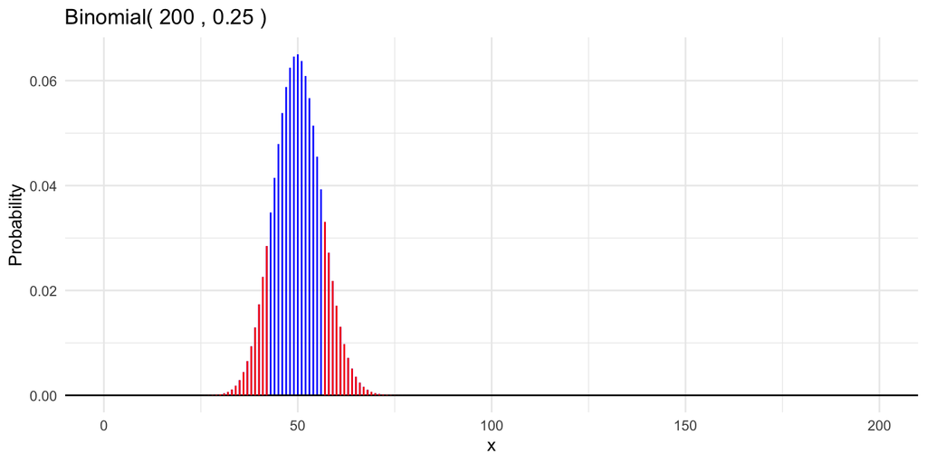

```r
gbinom(200, 0.25) +
  geom_binom_density(200, 0.25, b = 42, color = "red") +
  geom_binom_density(200, 0.25, a = 57, color = "red")
```

- Our p-value is thus:

```r
# Left side + right side (right side is the one we already calculated, left side is a more straightforward pbinom)
pbinom(42, 200, 0.25) + pbinom(57 - 1, 200, 0.25, lower.tail = FALSE)
```

```
## [1] 0.2534292
```

- And our interpretation remains the same, since the p-value > 0.05.
- If we had considered this “two-sided” alternative hypothesis and gotten a **significant** p-value, we would conclude we have **strong evidence the psychic was not picking randomly**, but we could not infer **whether they were better or worse than random**, since our alternative hypothesis included both directions.

# Inference on a Difference of Proportions

- The previous sections considered inference on **a single proportion.**
- However, many real questions consider inference on **a difference between two proportions.**

> Inference on **a difference between two proportions** is more complex than just doing single-proportion inference twice and subtracting. It uses the same conceptual framework, but with a different test statistic and sampling distribution.

## CI for a Difference of Proportions

- An inference question that is answered by a confidence interval for a difference in proportions is:

> What is our estimate of the difference between the probability chimpanzee C makes the prosocial choice WITH a partner and the probability chimpanzee C makes the prosocial choice WITHOUT a partner?

> **We do not care about the individual values of $p_1$ and $p_2$; only their difference!**
- Do **NOT** just create a CI for $p_1$ and a CI for $p_2$ and subtract them!
- Recall the general form of a confidence interval:

$$\text{Point Estimate } \pm \text{ Quantile Confidence Score * Standard
Error of PE}$$

- Intuitively, our point estimate of the difference in true proportions $p_1 - p_2$ is $\hat{p_1} - \hat{p_2}$, the difference in sample proportions.

```r
chimpanzee %>%
  filter(actor == "C") %>%
  mutate(HasAPartner = (partner == "none")) %>%
  group_by(HasAPartner) %>%
  summarize(totalProsocial = sum(prosocial),
            totalSelfish = sum(selfish),
            n = totalProsocial + totalSelfish,
            p_hat = totalProsocial/n)
```

```
## # A tibble: 2 × 5
##   HasAPartner totalProsocial totalSelfish     n p_hat
##   <lgl>                <dbl>        <dbl> <dbl> <dbl>
## 1 FALSE                   57           33    90 0.633
## 2 TRUE                    17           13    30 0.567
```

- Our point estimate for the difference in proportions is 63.3 - 56.7 = 6.6%.

### Sampling Distribution of Difference in Sample Proportions

- To determine the quantile confidence score and standard error, we have to know the **sampling distribution** of our point estimate.
- It can be verified through theory that:

> The sampling distribution of $\hat{p_1} - \hat{p_2}$ is $N(p_1 - p_2, SE(\hat{p_1} - \hat{p_2}))$, where the standard error is $\text{SE}(\hat{p}_1 - \hat{p}_2) = \sqrt{ \text{SE}(\hat{p}_1)^2 + \text{SE}(\hat{p}_2)^2 } = \sqrt{ \frac{p_1(1-p_1)}{n_1} + \frac{p_2(1-p_2)}{n_2} }$.
- There are two important conclusions here:
1. The sampling distribution is normal, so we can continue to use `qnorm` in our calculation of the quantile confidence score.
2. The standard error is known, but based on $p$; so we will have to make an adjustment, as we did for a single proportion.

### Agresti-Coffe Adjustment for p1-p2

> The **Agresti-Coffe** adjustment can be thought of as the **difference in proportions** version of the single proportion **Agresti-Coull** adjustment.

> $\hat{p_{1AC}} = \frac{X_1 + 1}{n_1 + 2}$, and $\hat{p_{2AC}} = \frac{X_2 + 1}{n_2 + 2}$. These adjustments carry through to the calculations of the point estimate and standard error.
- With the Agresti-Coffe adjustment,

$$\text{SE}(\hat{p}_{1AC} - \hat{p}_{2AC}) = \sqrt{
\frac{\hat{p}_{1AC}(1-\hat{p}_{1AC})}{n_1+2} +
\frac{\hat{p}_{2AC}(1-\hat{p}_{2AC})}{n_2+2} }$$

### Final Formula

- Using the Agresti-Coffe adjustment, we can finally arrive at our final form for a confidence interval for a difference in proportions:

$$\hat{p_{1AC}} - \hat{p_{2AC}} \pm \text{qnorm(C + (1-C)/2)} * \sqrt{
\frac{\hat{p}_{1AC}(1-\hat{p}_{1AC})}{n_1+2} +
\frac{\hat{p}_{2AC}(1-\hat{p}_{2AC})}{n_2+2} }$$

```r
# Four inputs: Observed successes and sample size in group 1, X1 and n1, and for group2, X2 and n2
x1 = 57
n1 = 90
x2 = 17
n2 = 30

# Confidence level
alpha = 0.95

# We will use "tilde" to refer to the AC-adjusted statistics
# This code computes the AC Confidence Interval for the true difference in two proportions
ntilde1 = n1 + 2
ntilde2 = n2 + 2
ptilde1 = (x1+1)/ntilde1
ptilde2 = (x2+1)/ntilde2

pe = ptilde1 - ptilde2

se1 = sqrt( ptilde1*(1-ptilde1)/ntilde1 )
se2 = sqrt( ptilde2*(1-ptilde2)/ntilde2 )
se = sqrt(se1^2 + se2^2 )
moe = qnorm(alpha + (1 - alpha)/2) * se

left = pe - moe
right = pe + moe

c(left, right)
```

```
## [1] -0.1302339  0.2661035
```

- We are NOT constructing a confidence interval for a single proportion - we are constructing a confidence interval for $p_1 - p_2$, a **difference in proportions**. That **difference can be negative!**
- In context, we would interpret this as:

> We are 95% confident that when Chimpanzee C has a partner, the change in the probability of making a prosocial choice compared to no partner is between -13% and +26.6%.

## Hypothesis Testing for a Difference of Proportions

- An inference question that could be answered with a difference in proportions hypothesis test is:

> Is the true probability of chimpanzee C making the pro-social choice HIGHER when there is a partner in the neighboring room?
- Alternatively, to better reflect the technical details of the test:

> Is the difference between the probability chimpanzee C makes the prosocial choice WITH a partner and the probability chimpanzee C makes the prosocial choice WITHOUT a partner 0 or greater than 0?

### Step 1: Statistical Model

- $X_1$ is the observed number of pro-social choices of Chimpanzee C with a partner from $n_1 = 90$ trials.
- $X_2$ is the observed number of pro-social choices of Chimpanzee C with NO partner from $n_2 = 30$ trials.
- $p_1$ is the true probability that Chimpanzee C makes the pro-social choice when there is a partner.
- $p_2$ is the true probability that Chimpanzee C makes the pro-social choice when there is no partner.

$$X_1 \sim \text{Binomial}(90,p_1) \\
X_2 \sim \text{Binomial}(30,p_2)$$

We do not list out the BINS assumptions here, but we may assume that they are met.

### Step 2: State Hypotheses

- Recall that the null hypothesis captures the idea there is **no pattern or relationship**. This extends to the idea of there being **no difference** in two parameter values.

$$H_0: p_1 = p_2$$

$$H_A: p_1 > p_2$$

> This step makes it appear as if we care about the individual values of $p_1$ and $p_2$. **We do not care about their individual values; only their difference!**
- Knowing that $p_1 - p_2 > 0$ is all we care about!
- To emphasize this conceptual point, we often write these hypotheses in this equivalent way:

$$H_0: p_1 - p_2 = 0, H_A: p_1 - p_2 > 0$$

### Step 3: Test Statistic and Null Distribution

- I promised you that the test statistics would get more complicated… here we are!
- We know from the confidence intervals section that $\hat{p_1} - \hat{p_2} \sim N(p_1 - p_2, SE(\hat{p_1} - \hat{p_2}))$.
- We can standardize this to:

$$T = \frac{(\hat{p_1} - \hat{p_2}) - (p_1 - p_2)}{SE(\hat{p_1} -
\hat{p_2})} \sim N(0, 1)$$

- Our null hypothesis says that $p_1 - p_2 = 0$, so that term goes away.
- However, $SE(\hat{p_1} - \hat{p_2}) = \sqrt{ \frac{p_1(1-p_1)}{n_1} + \frac{p_2(1-p_2)}{n_2}}$ is still based on $p_1$ and $p_2$. The null hypothesis doesn’t give us specific values, it just says that they are equal.
- We make a slight “adjustment” here to account for this. If there is some $p$ such that $p_1 = p_2 = p$, then the standard error becomes $\sqrt{ \frac{p(1-p)}{n_1} + \frac{p(1-p)}{n_2}}$, and now we just need to estimate $p$.
- We estimate $p$ with the global proportion of successes across both groups: $\bar{p} = \frac{X_1 + X_2}{n_1 + n_2}$.
- Finally, our test statistic and null distribution are:

$$\frac{(\hat{p_1} - \hat{p_2}) - (0)}{\sqrt{
\frac{\bar{p}(1-\bar{p})}{n_1} + \frac{\bar{p}(1-\bar{p})}{n_2}}} \sim
N(0, 1)$$

### Step 4: Identify Relevant Outcomes from Data + Alt. Hyp

- Our observed value of the test statistic is:

```r
x1 = 57
n1 = 90
x2 = 17
n2 = 30

pbar = (x1 + x2)/(n1+n2)

numerator = (x1/n1) - (x2/n2)
denominator = sqrt((pbar*(1-pbar)/n1) + (pbar*(1-pbar)/n2))

test_stat = numerator/denominator
test_stat
```

```
## [1] 0.6504089
```

- This test statistic, which is a standardized score for the difference in sample proportions, is 0.65.

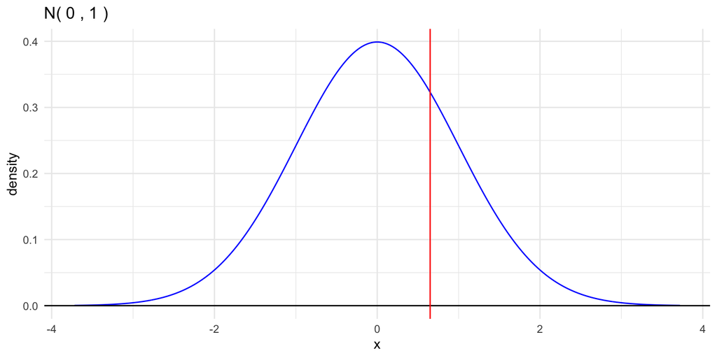

```r
# Null distribution was N(0, 1)
gnorm() +
  geom_vline(xintercept = test_stat, color = "red")
```

- The outcomes which are as or less likely than `test_stat` on our null distribution are $X \geq 0.65$ and $X \leq -0.65$, because the normal distribution is symmetric.
- However, only $X \geq 0.65$ constitutes evidence for our alternative hypothesis, $H_A: p_1 > p_2$.

### Step 5: Calculate a P-Value

- The p-value is the probability of getting the outcomes identified in step 4 on the null distribution.
- Here, this is $P(N(0,1) \geq 0.65)$.
- Recall: continuous areas, caution to the wind! We are still calculating an area to the right so we use `1 -` or `lower.tail = FALSE`, but we don’t need to adjust `test_stat` at all.

```r
1 - pnorm(test_stat, mean = 0, sd = 1)
```

```
## [1] 0.2577141
```